# Part I - (Ford-Go-Bike, Bike-Sharing System)

## by LEONE ARINA

## Investigation Overview

> This presentaion will look ar the composition of the different users, the age distribution of users, the ride durations and the general demand for the service during each day of thw week.

## The Start Day

> The visualization below shows the day the ride was made. This helps to how the comparison for the demand of the servive through out each day of the week.

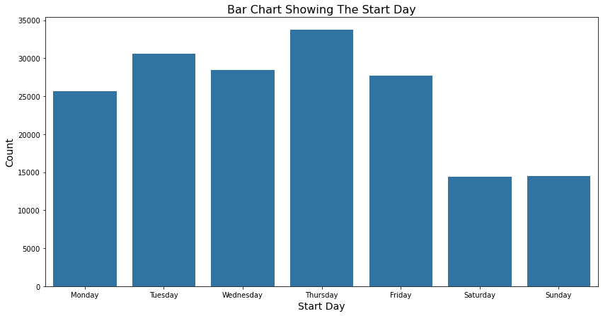

> This shows that Thursday was the most common day to hire a bike with weekends having the least. This maybe due to the fact that the weekdays are work days and thus the users used the service to beat triffic or get somewhere fater.

## The Type Of Users

> This is a pie chart showing the Type of Uses if they are Subscribers or walk in Customers

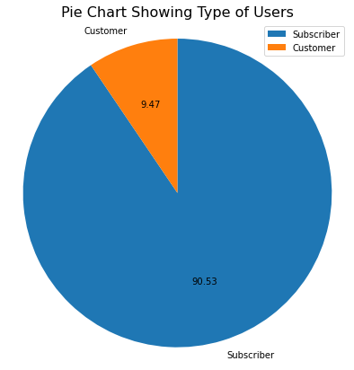

> This shows that majority of the users were Subscribed to Ford-Go-Bikes constituting of 90.53%

## The Users Age Distribution

> This is a histogram showing the age distribution of the users.

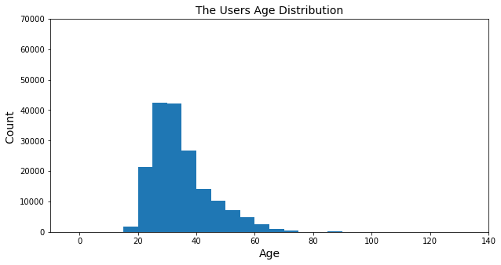

> It can be seen that the Average age of most users was between 20-45years.

## The Ride Duration

> This is ahistogram showing the ride duration

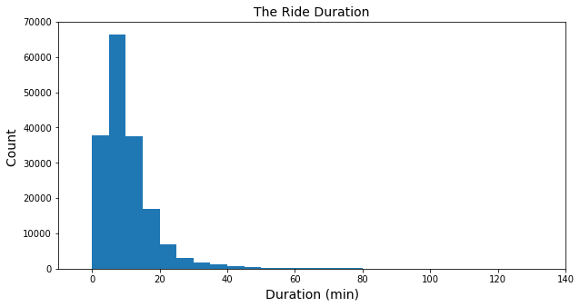

Most rides durations were averagly between 0-25minutes

[output not shown]